# Clusterización

Francisco Javier Gutiérrez Expósito

```
## date: Mon Feb  1 02:35:46 2016
```

Medicamentos que se consideran como ATCs para Diabéticos:A10AB,A10AC,A10AD,A10AE,A10AF,A10BA,A10BB,A10BC,A10BD,A10BF,A10BG,A10BH,A10BX,A10XA,

# Revisión de Gráficas para la memoria.

A continuación se muestran los datos seguidos para hacer una revisión de la clusterización. Se van a utilizar tres algoritmos para ver si se identifican resultados distintos:

1. DBSCAN. Este método agrupa de forma conjunta todos los elementos que tiene algún elemento de ese cluster a la distancia especificada. Dependiendo de la estructura de los datos puede tener resultados mejores que el K-MEANS. Toma como input la distancia que se quiere establecer entre los elementos, y, suele comenzar la parte de prueba de distancia a partir de la curva de inflexión de la curva de los K-vecinos más cercanos.
2. K-MEANS. Este método pone puntos céntricos aleatorios (llamados centroides) y a partir de esos puntos comienza a calcular la distancia de todos los puntos a los centroides para agrupar. Toma como input el número de centroides de partida y el número de veces que se quiere que el algoritmo itere.
3. JERÁRQUICO. Este método genera tantos cluster al principio como elementos hay en el juego de datos. A partir de ahí comienza a agrupar en base a la distancia. No toma como partida ningún dato.

## DBSCAN

### Alternativa 1: Sin eliminar outliers y Variables generadas

Sexo Edad totalATCDiabeticos totalATCOtros numATCDiabeticos numATCOtros

#### Año: 2011

En las gráficas vamos a marcar varias líneas: Valor 0.3 (gris), Valor 0.5 (azul), Valor 1 (roja) y Valor 1.5 (verde). Eso solo es para tener una referencia de cara a identificar mejor cuál es el mejor punto de cara a la inflexión.

Se puede observar como existen elementos que probablemente sean outliers. Estos elementos afectarán al algoritmo de DBSCAN, ya que los outliers no le sientan bien. TODO: Buscar referencias de Outliers para este algoritmo.

–>Media de la distancia: 0.3

**Distancia: 1**

–>Número de elementos mínimos: 20

#### Distancia 0.3

##### Elementos 5

[figure not shown]

##### Elementos 15

##### Elementos 20

##### Elementos 25

##### Elementos 50

#### Distancia 0.5

##### Elementos 5

##### Elementos 10

##### Elementos 15

##### Elementos 20

##### Elementos 25

##### Elementos 50

#### Distancia 1

##### Elementos 5

##### Elementos 10

##### Elementos 15

##### Elementos 20

##### Elementos 25

##### Elementos 50

#### Distancia 1.5

##### Elementos 5

##### Elementos 10

##### Elementos 15

##### Elementos 20

##### Elementos 25

##### Elementos 50

#### Año: 2012

**Gráfica CLUST.DBSCAN.1 - K-Vecinos[min=5] cercarnos para 2012**

En las gráficas vamos a marcar varias líneas: Valor 0.3 (gris), Valor 0.5 (azul), Valor 1 (roja) y Valor 1.5 (verde). Eso solo es para tener una referencia de cara a identificar mejor cuál es el mejor punto de cara a la inflexión.

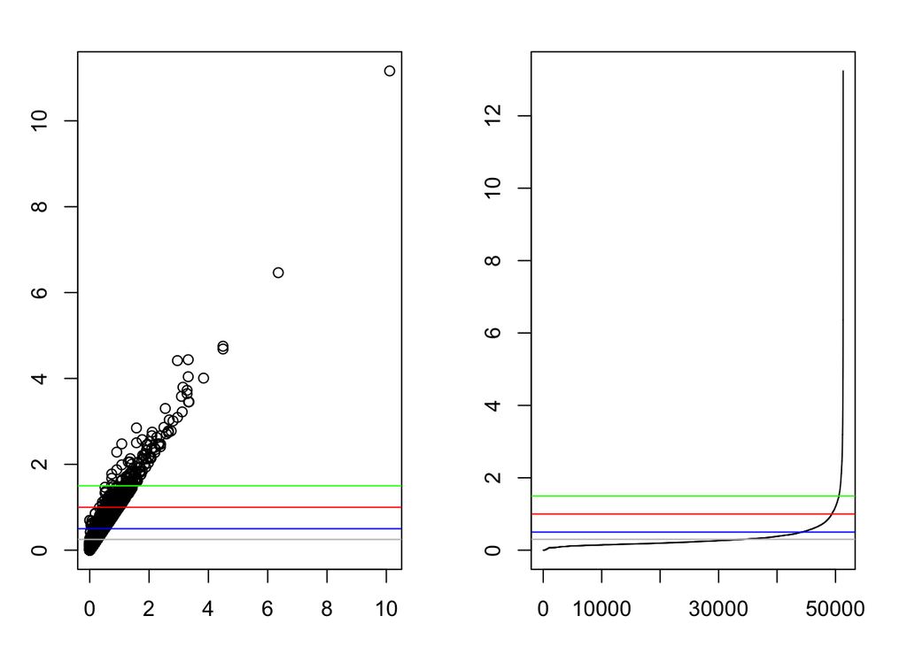

Se puede observar como existen elementos que probablemente sean outliers. Estos elementos afectarán al algoritmo de DBSCAN, ya que los outliers no le sientan bien. TODO: Buscar referencias de Outliers para este algoritmo.

–>Media de la distancia: 0.32

**Distancia: 1**

–>Número de elementos mínimos: 20

#### Distancia 0.3

##### Elementos 5

##### Elementos 10

##### Elementos 15

##### Elementos 20

##### Elementos 25

##### Elementos 50

#### Distancia 0.5

##### Elementos 5

##### Elementos 10

##### Elementos 15

##### Elementos 20

##### Elementos 25

##### Elementos 50

#### Distancia 1

##### Elementos 5

##### Elementos 10

##### Elementos 15

##### Elementos 20

##### Elementos 25

##### Elementos 50

#### Distancia 1.5

##### Elementos 5

##### Elementos 10

##### Elementos 15

##### Elementos 20

##### Elementos 25

##### Elementos 50

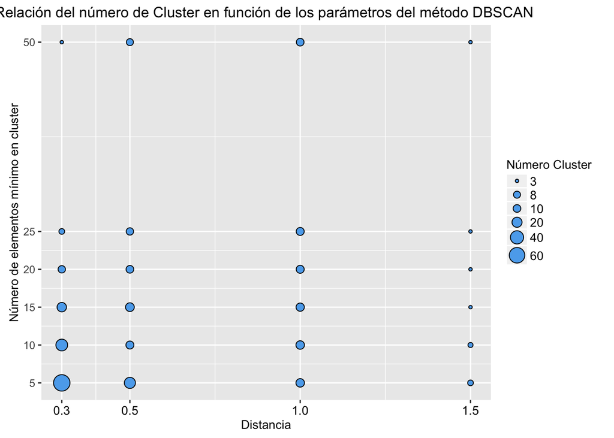

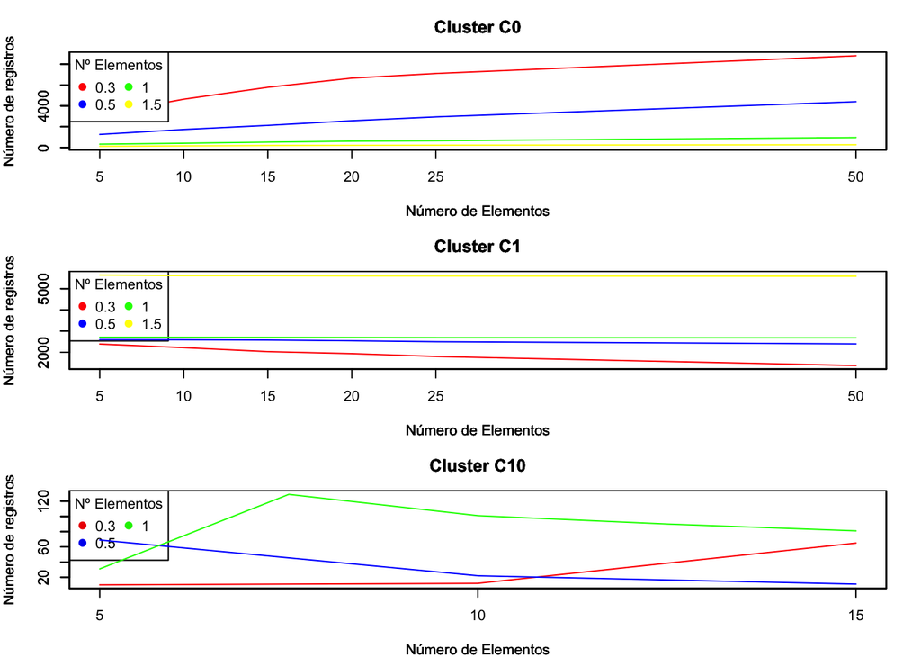

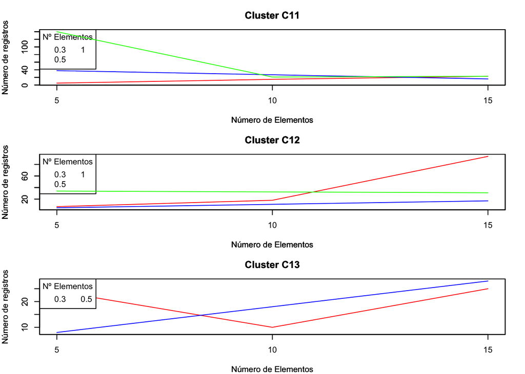

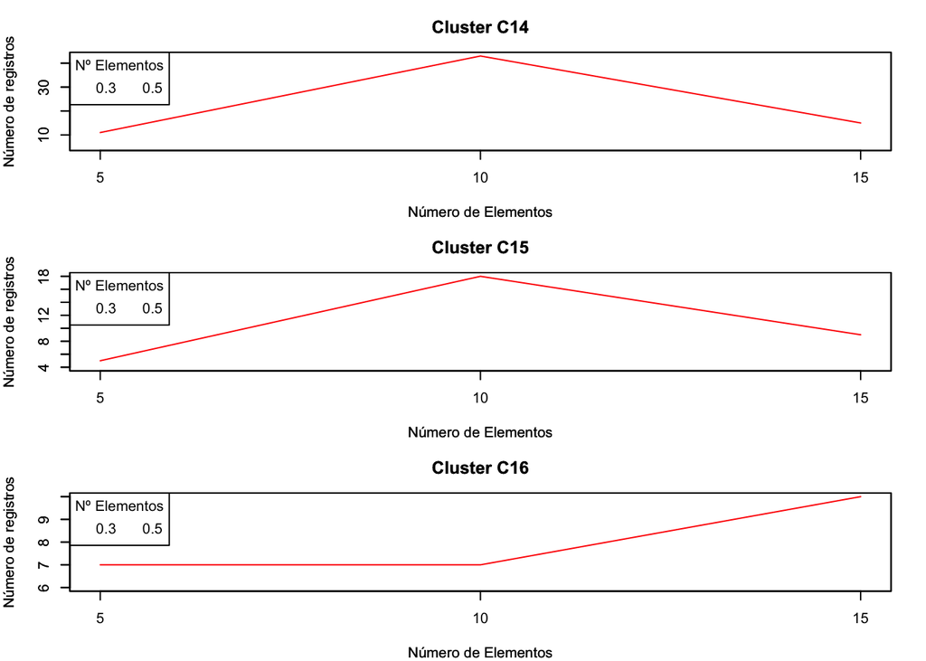

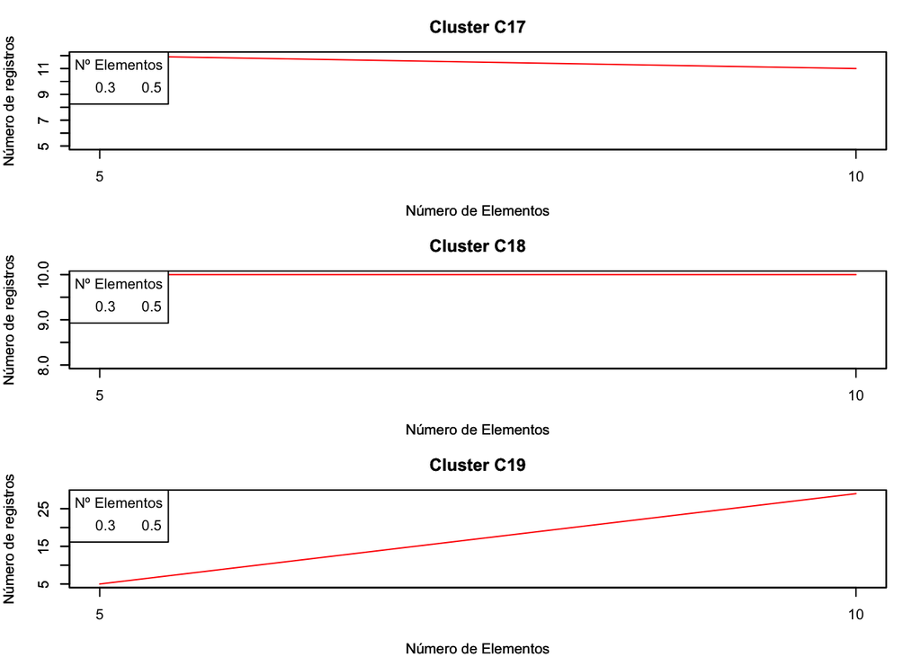

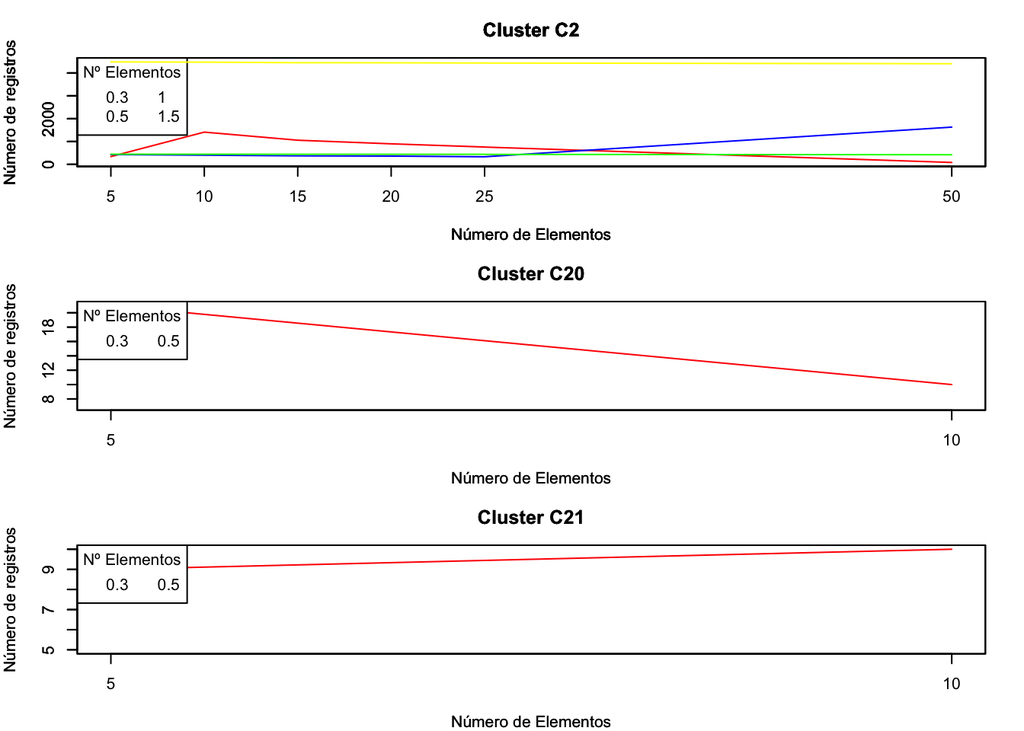

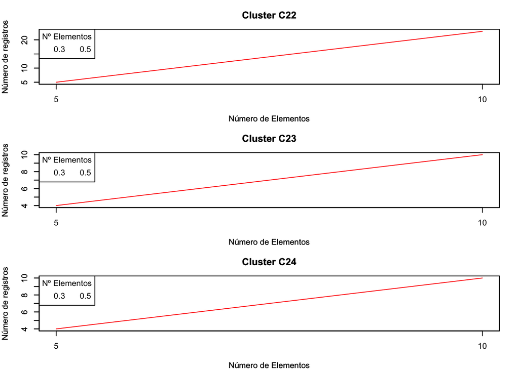

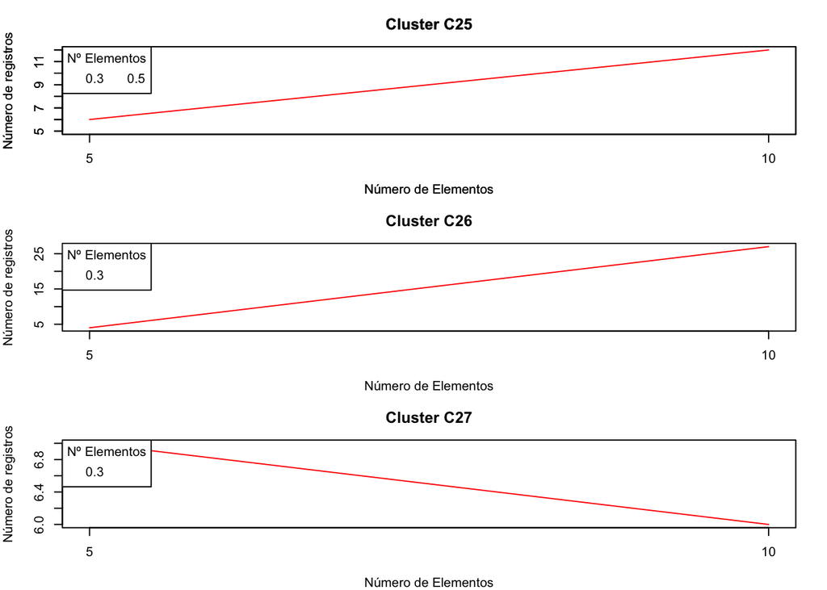

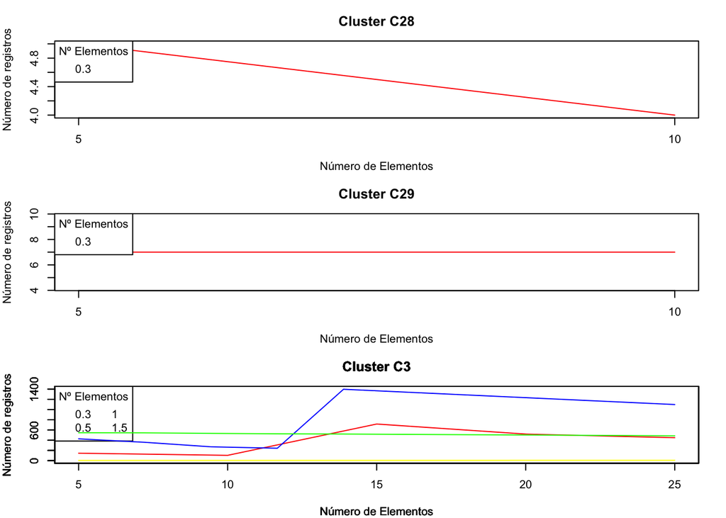

[figure not shown]

[figure not shown]

[figure not shown]

[12 more figures not shown]

ggplot(df, aes(x=Distancia, y=NumElem, size=Cluster)) + geom_point(shape=21, fill=“steelblue2”) + scale_x_continuous(name=“Distancia”, breaks=unique(df$Distancia)) + scale_y_continuous(name="Número de elementos mínimo en cluster", breaks=unique(df$NumElem)) + scale_size(“Número Cluster”, breaks=c(3, 8, 10, 20, 40, 60)) + theme(axis.text.x = element_text(size = 10, colour = “black”)) + theme(title = element_text(size = 10, colour = “black”)) + theme(legend.text = element_text(size = 10)) + theme(legend.key.height = unit (0.4, “cm”)) + labs(title=“Relación del número de Cluster en función de los parámetros del método DBSCAN”)

d <- d11.m d.m <- as.data.frame(d.m)

# Cluster 0

n <- 5

dm <- d.m d.m <- as.data.frame(d.m)

# Cluster

table(d.m[d.m$DBSCAN==n, “DBSCAN”]) summary(d.m[d.m$DBSCAN==n, “Edad”]) table(d.m[d.m$DBSCAN==n, “Sexo”])/nrow(d.m[d.m$DBSCAN==n,]) table(d.m[d.m$DBSCAN==n, “CRG”]) #summary(d.m[d.m$DBSCAN==n, “totalATCTodos”]) #summary(d.m[d.m$DBSCAN==n, “numATCTodos”]) summary(d.m[d.m$DBSCAN==n, “totalATCDiabeticos”] + d.m[d.m$DBSCAN==n, “totalATCOtros”]) qplot(d.m[d.m$DBSCAN==n, “totalATCOtros”], d.m[d.m$DBSCAN==n, “totalATCDiabeticos”], geom=“boxplot”) summary(d.m[d.m$DBSCAN==n, “numATCDiabeticos”] + d.m[d.m$DBSCAN==n, “numATCOtros”])